# Contents

# 0 Introduction

This time we are provided MNIST data from Kaggle. MNIST data is collection of 70,000 handwritten digits images. Our goal is to build a model that classify each image of MNIST data to 10 different class or digit (0, 1, 2, 3, 4, 5, 6, 7, 8, and 9). The data is separated between the training and test dataset with the 60:40 proportion. In other to evaluate our model, we need to match our predicted data to the actual data in the Kaggle website.

We want to make prediction models using Convolutional Neural Network (CNN). The MNIST image originally in 28x28 format but the data from kaggle is in flatenned format so we need to do some preprocessing to convert it to the original image dimension.

# 1 Importing & Preprocessing Data

```python
# Load common libraries
import sys
import tensorflow as tf
import pandas as pd
import numpy as np
import matplotlib.pyplot as plt

print("Python version: {}". format(sys.version))
print("TensorFlow version:", tf.__version__)
print("Pandas version:", pd.__version__)
print("Numpy version:", np.__version__, "\n")

# We want to make sure that we use GPU for a faster training
print("Num GPUs Available: ", len(tf.config.list_physical_devices('GPU')))
```

```
Python version: 3.7.16 (default, Jan 17 2023, 16:06:28) [MSC v.1916 64 bit (AMD64)]
TensorFlow version: 2.11.0
Pandas version: 1.3.5
Numpy version: 1.21.6

Num GPUs Available:  0
```

## 1.1 Load Data

```python
# Import data
train = pd.read_csv("train.csv")
test = pd.read_csv("test.csv")

print(type(train))
print("train shape: ", train.shape)
print("test shape: ", test.shape, "\n")

# Split the features and labels
x_train, y_train = train.iloc[:, 1:], train['label']

# Convert the data into numpy array
x_train = x_train.to_numpy()
y_train = y_train.to_numpy()
x_test = test.to_numpy()

print(type(x_train))
print("x_train shape: ", x_train.shape)
print("y_train shape: ", y_train.shape)
print("x_test shape: ", x_test.shape, "\n")

# Check the data proportion
print("train data: ", (len(x_train)/(len(x_train)+len(x_test)))*100, "%")
print("test data: ", (len(x_test)/(len(x_train)+len(x_test)))*100, "%")
```

```
<class 'pandas.core.frame.DataFrame'>
train shape:  (42000, 785)
test shape:  (28000, 784)

<class 'numpy.ndarray'>
x_train shape:  (42000, 784)
y_train shape:  (42000,)
x_test shape:  (28000, 784)

train data:  60.0 %
test data:  40.0 %
```

```python
# Peek the data
y_train
```

```
array([1, 0, 1, ..., 7, 6, 9], dtype=int64)
```

## 1.2 Visualize Data

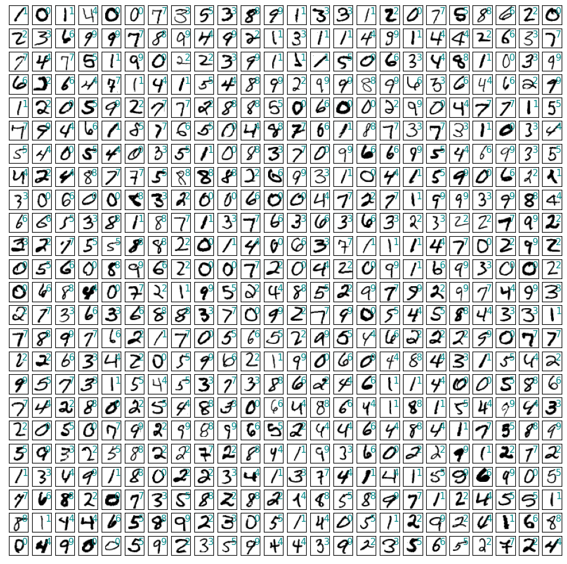

```python
fig, axs = plt.subplots(24, 24, figsize=(12, 12))
index = 0

for i in range(24):
    for j in range(24):

        axs[i, j].imshow(x_train[index].reshape(28, 28), cmap="binary")
        axs[i, j].set_xticks([])
        axs[i, j].set_yticks([])
        axs[i, j].text(x=19, y=12, s=str(y_train[index]), c='darkcyan', size=11)
        index += 1
```

## 1.3 Preprocessing Data

```python
print(type(y_train))
print("y_train: ", y_train.shape, "\n")

# Convert the label variable to categorical
# label encoding
from tensorflow.keras.utils import to_categorical
class_names = ['0', '1', '2', '3', '4', '5', '6', '7', '8', '9']
y_train = to_categorical(y_train, len(class_names))
print(type(y_train))
print("y_train: ", y_train.shape, "\n")

# Standardize the pixel value
x_train = x_train / 255
x_test = x_test / 255
print(type(x_train))
print("x_train: ", x_train.shape)
print("x_test: ", x_test.shape, "\n")

# Convert numpy to tensorflow tensor
x_train = tf.convert_to_tensor(x_train, dtype=tf.float32)
y_train = tf.convert_to_tensor(y_train, dtype=tf.float32)
x_test = tf.convert_to_tensor(x_test, dtype=tf.float32)
print(type(x_train))
print("x_train: ", x_train.shape)
print("x_test: ", x_test.shape)
print(type(y_train))
print("y_train: ", y_train.shape, "\n")

# Reshape the dimension for CNN (from flatenned to standard image dimension)
import tensorflow.python.ops.numpy_ops.np_config as np_config
np_config.enable_numpy_behavior()
x_train = x_train.reshape(x_train.shape[0], 28, 28, 1)
x_test = x_test.reshape(x_test.shape[0], 28, 28, 1)
print(type(x_train))
print("x_train: ", x_train.shape)
print("x_test: ", x_test.shape, "\n")
```

```
<class 'numpy.ndarray'>
y_train:  (42000,)

<class 'numpy.ndarray'>
y_train:  (42000, 10)

<class 'numpy.ndarray'>
x_train:  (42000, 784)
x_test:  (28000, 784)

<class 'tensorflow.python.framework.ops.EagerTensor'>
x_train:  (42000, 784)
x_test:  (28000, 784)
<class 'tensorflow.python.framework.ops.EagerTensor'>
y_train:  (42000, 10)

<class 'tensorflow.python.framework.ops.EagerTensor'>
x_train:  (42000, 28, 28, 1)
x_test:  (28000, 28, 28, 1)
```

Data normalization is important to speed up the training process. Normalization would cause the back-propagation converges much faster

## 1.4 Adding Validation Data

Typically we use 20% of training data for validation data

```python
from sklearn.model_selection import train_test_split
x_train_train, x_train_val, y_train_train, y_train_val = train_test_split(x_train, y_train, test_size=0.2, random_state=0)

print(type(x_train))
print("x_train_train: ", x_train_train.shape)
print("x_train_val: ", x_train_val.shape)
print(type(y_train))
print("y_train_train: ", y_train_train.shape)
print("y_train_val: ", y_train_val.shape)
```

```
<class 'tensorflow.python.framework.ops.EagerTensor'>
x_train_train:  (33600, 28, 28, 1)
x_train_val:  (8400, 28, 28, 1)
<class 'tensorflow.python.framework.ops.EagerTensor'>
y_train_train:  (33600, 10)
y_train_val:  (8400, 10)
```

## 1.5 Augmenting Train & Validation Data

In order to avoid overfitting problem, we need to expand artificially our handwritten digit dataset. We can make your existing dataset even larger. The idea is to alter the training data with small transformations to reproduce the variations occuring when someone is writing a digit.

For example, the number is not centered The scale is not the same (some who write with big/small numbers) The image is rotated...

Approaches that alter the training data in ways that change the array representation while keeping the label the same are known as data augmentation techniques. Some popular augmentations people use are grayscales, horizontal flips, vertical flips, random crops, color jitters, translations, rotations, and much more.

By applying just a couple of these transformations to our training data, we can easily double or triple the number of training examples and create a very robust model.

```python
# Got this idea from https://www.kaggle.com/elcaiseri
# With data augmentation to prevent overfitting

from keras.preprocessing.image import ImageDataGenerator
datagen = ImageDataGenerator(
        featurewise_center=False,  # set input mean to 0 over the dataset
        samplewise_center=False,  # set each sample mean to 0
        featurewise_std_normalization=False,  # divide inputs by std of the dataset
        samplewise_std_normalization=False,  # divide each input by its std
        zca_whitening=False,  # apply ZCA whitening
        rotation_range=15,  # randomly rotate images in the range (degrees, 0 to 180)
        zoom_range = 0.01, # Randomly zoom image
        width_shift_range=0.1,  # randomly shift images horizontally (fraction of total width)
        height_shift_range=0.1,  # randomly shift images vertically (fraction of total height)
        horizontal_flip=False,  # randomly flip images
        vertical_flip=False)  # randomly flip images


#datagen.fit(X_train)
train_train_gen = datagen.flow(x_train_train, y_train_train, batch_size=128)
train_val_gen = datagen.flow(x_train_val, y_train_val, batch_size=128)
```

**I did not apply a vertical_flip nor horizontal_flip since it could have lead to misclassify symetrical numbers such as 6 and 9.**

Once our model is ready, we fit the training dataset .

# 2 Modelling & Training

## 2.1 1st-Model

### 2.1.1 1st-Model Algorithm

```python
from keras.models import Sequential
from keras.layers import Conv2D, Lambda, MaxPooling2D
from keras.layers import Dense, Dropout, Flatten
from tensorflow.keras.layers import BatchNormalization

model=Sequential() #model.add(Lambda(standardize,input_shape=(28,28,1)))
model.add(Conv2D(filters=64, kernel_size = (3,3), activation="relu", input_shape=(28,28,1)))
model.add(Conv2D(filters=64, kernel_size = (3,3), activation="relu"))
model.add(MaxPooling2D(pool_size=(2,2)))
model.add(BatchNormalization())
model.add(Conv2D(filters=128, kernel_size = (3,3), activation="relu"))
model.add(Conv2D(filters=128, kernel_size = (3,3), activation="relu"))
model.add(MaxPooling2D(pool_size=(2,2)))
model.add(BatchNormalization())
model.add(Conv2D(filters=256, kernel_size = (3,3), activation="relu"))
model.add(MaxPooling2D(pool_size=(2,2)))
model.add(BatchNormalization())
model.add(Flatten())
model.add(Dense(512,activation="relu"))
model.add(Dense(10,activation="softmax"))

model.compile(loss="categorical_crossentropy", optimizer="adam", metrics=["accuracy"])

model.summary()
```

```
Model: "sequential_2"
_________________________________________________________________
 Layer (type)                Output Shape              Param #
=================================================================
 conv2d_2 (Conv2D)           (None, 26, 26, 64)        640

 conv2d_3 (Conv2D)           (None, 24, 24, 64)        36928

 max_pooling2d_1 (MaxPooling  (None, 12, 12, 64)       0
 2D)

 batch_normalization (BatchN  (None, 12, 12, 64)       256
 ormalization)

 conv2d_4 (Conv2D)           (None, 10, 10, 128)       73856

 conv2d_5 (Conv2D)           (None, 8, 8, 128)         147584

 max_pooling2d_2 (MaxPooling  (None, 4, 4, 128)        0
 2D)

 batch_normalization_1 (Batc  (None, 4, 4, 128)        512
 hNormalization)

 conv2d_6 (Conv2D)           (None, 2, 2, 256)         295168

 max_pooling2d_3 (MaxPooling  (None, 1, 1, 256)        0
 2D)

 batch_normalization_2 (Batc  (None, 1, 1, 256)        1024
 hNormalization)

 flatten (Flatten)           (None, 256)               0

 dense (Dense)               (None, 512)               131584

 dense_1 (Dense)             (None, 10)                5130

=================================================================
Total params: 692,682
Trainable params: 691,786
Non-trainable params: 896
_________________________________________________________________
```